# 00a. RIntro

Dean Adams, Michael Collyer & Antigoni Kaliontzopoulou

3/14/2019

## **Content description**

A basic knowledge of R is a requirement for following this course, and it will be considered a standard during the labs. However, here we provide you a short guide to some basic operations, as a resource for solving some basic practical problems you might encounter. We encourage you to sharpen your R skills as much as possible in the future. It is a great tool, and an ever-learning path to follow!

R is a statistical programming environment with many built-in mathematical functions and many others that are found in packages that can be installed. Geomorph is one such package.

Analyses in R are performed using a series of commands which are written in script files and passed to the main console. The general workflow is: 1. OPEN R or Rstudio 2. OPEN R-script 3. Define your working directory 4. Run analyses

## **Some R basics**

```r
3 -> a  # Assign value to variable
a
```

```
## [1] 3
```

```r
b <- c(3,4,5)   # 'c' combines values into vector or list
b
```

```
## [1] 3 4 5
```

```r
b[2]    # Access items in vectors by calling their position (aka indexing)
```

```
## [1] 4
```

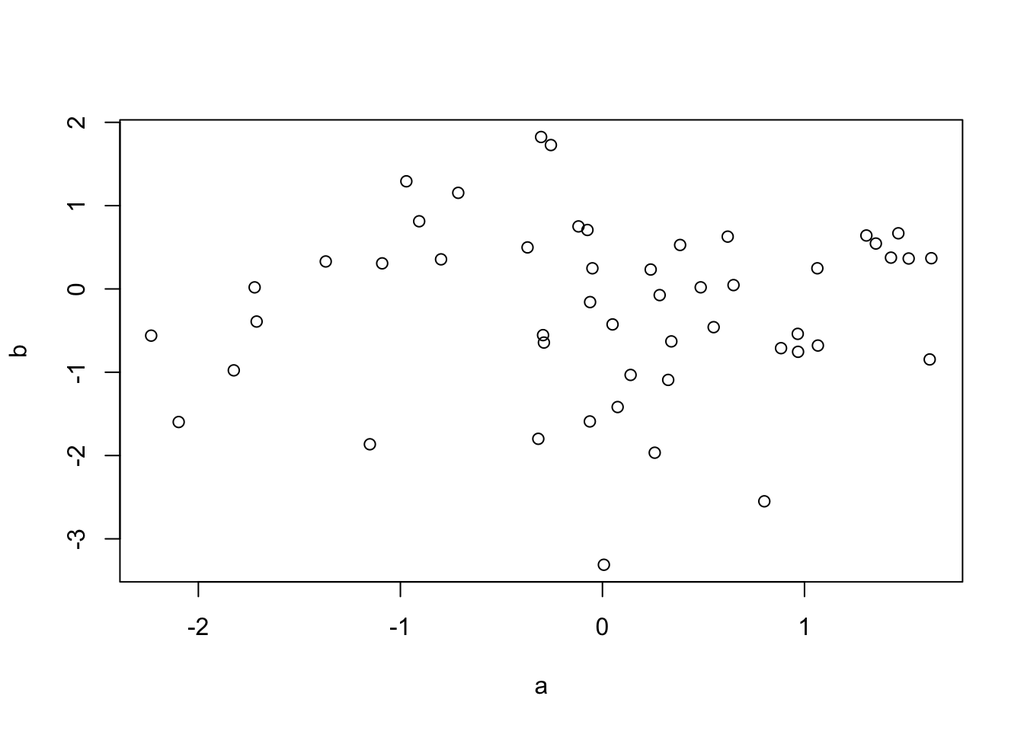

```r
a <- rnorm(50) # Generate random normal vector
b <- rnorm(a)
plot(a, b)      # A simple plot
```

```r
c <- cbind(a, b)    # Binds columns together (rbind does same by rows)
c
```

```
##                  a           b
##  [1,]  0.139303150 -1.03239303
##  [2,]  0.801091728 -2.54953386
##  [3,] -1.151132751 -1.86483275
##  [4,] -0.118569298  0.75063851
##  [5,]  0.075200553 -1.41786200
##  [6,]  0.258768947 -1.96617522
##  [7,]  0.283205869 -0.07404481
##  [8,] -1.824654620 -0.97741248
##  [9,]  0.007046074 -3.31146466
## [10,]  0.968158126 -0.75465296
## [11,] -1.711640902 -0.39147698
## [12,]  0.486268342  0.01936228
## [13,] -2.097326313 -1.59748994
## [14,]  1.066351390 -0.67940497
```

[output cut: 36 more lines]

```r
c[1]   # first element
```

```
## [1] 0.1393031
```

```r
c[1,]    # first row
```

```
##          a          b
##  0.1393031 -1.0323930
```

```r
c[,1]  # first column
```

```
##  [1]  0.139303150  0.801091728 -1.151132751 -0.118569298  0.075200553
##  [6]  0.258768947  0.283205869 -1.824654620  0.007046074  0.968158126
## [11] -1.711640902  0.486268342 -2.097326313  1.066351390 -0.970588132
## [16] -0.294045340 -1.721479772 -1.090217157  1.619682010 -0.061134350
## [21] -2.233611817  1.464556207 -0.049742247  0.341003435  0.384357009
## [26] -0.907105827 -0.303634731  1.353216425 -0.074219503  1.427943283
## [31]  1.627838424 -0.370791334  0.238696749  0.550364998 -1.369475473
## [36] -0.255153731  1.306241886  0.619949087  1.515602372  0.883898919
## [41]  0.049990141  1.063637481 -0.062411159  0.648648988 -0.713742910
## [46]  0.325423324  0.966665902 -0.289738529 -0.798872437 -0.317484679
```

```r
rbind(a,b)
```

```
##         [,1]       [,2]      [,3]       [,4]        [,5]       [,6]
## a  0.1393031  0.8010917 -1.151133 -0.1185693  0.07520055  0.2587689
## b -1.0323930 -2.5495339 -1.864833  0.7506385 -1.41786200 -1.9661752
##          [,7]       [,8]         [,9]      [,10]     [,11]      [,12]
## a  0.28320587 -1.8246546  0.007046074  0.9681581 -1.711641 0.48626834
## b -0.07404481 -0.9774125 -3.311464660 -0.7546530 -0.391477 0.01936228
##       [,13]     [,14]      [,15]      [,16]       [,17]      [,18]
## a -2.097326  1.066351 -0.9705881 -0.2940453 -1.72147977 -1.0902172
## b -1.597490 -0.679405  1.2922632 -0.5545496  0.01892392  0.3071866
##        [,19]       [,20]      [,21]     [,22]       [,23]      [,24]
## a  1.6196820 -0.06113435 -2.2336118 1.4645562 -0.04974225  0.3410034
## b -0.8464642 -0.15794141 -0.5605869 0.6681319  0.24777945 -0.6297717
##       [,25]      [,26]      [,27]     [,28]      [,29]    [,30]     [,31]
## a 0.3843570 -0.9071058 -0.3036347 1.3532164 -0.0742195 1.427943 1.6278384
## b 0.5278522  0.8123675  1.8241137 0.5450886  0.7078297 0.375741 0.3687567
##        [,32]     [,33]      [,34]      [,35]      [,36]     [,37]
## a -0.3707913 0.2386967  0.5503650 -1.3694755 -0.2551537 1.3062419
## b  0.4984717 0.2329349 -0.4589689  0.3298126  1.7273911 0.6415668
##       [,38]     [,39]      [,40]       [,41]     [,42]       [,43]
## a 0.6199491 1.5156024  0.8838989  0.04999014 1.0636375 -0.06241116
## b 0.6280939 0.3654644 -0.7111358 -0.42609543 0.2479117 -1.59080441
##        [,44]      [,45]      [,46]      [,47]      [,48]      [,49]
## a 0.64864899 -0.7137429  0.3254233  0.9666659 -0.2897385 -0.7988724
## b 0.04606408  1.1537182 -1.0920657 -0.5392652 -0.6437061  0.3552148
##        [,50]
## a -0.3174847
## b -1.7992379
```

```r
ls() # See which R objects are now in the R workspace
```

```
## [1] "a" "b" "c"
```

## **Some base functions**

```r
sum(a)
```

```
## [1] 1.686338
```

```r
mean(a)
```

```
## [1] 0.03372676
```

```r
min(a)
```

```
## [1] -2.233612
```

```r
max(a)
```

```
## [1] 1.627838
```

```r
var(a)
```

```
## [1] 1.00514
```

```r
a^2     # Square values
```

```
##  [1] 1.940537e-02 6.417480e-01 1.325107e+00 1.405868e-02 5.655123e-03
##  [6] 6.696137e-02 8.020556e-02 3.329364e+00 4.964716e-05 9.373302e-01
## [11] 2.929715e+00 2.364569e-01 4.398778e+00 1.137105e+00 9.420413e-01
## [16] 8.646266e-02 2.963493e+00 1.188573e+00 2.623370e+00 3.737409e-03
## [21] 4.989022e+00 2.144925e+00 2.474291e-03 1.162833e-01 1.477303e-01
## [26] 8.228410e-01 9.219405e-02 1.831195e+00 5.508535e-03 2.039022e+00
## [31] 2.649858e+00 1.374862e-01 5.697614e-02 3.029016e-01 1.875463e+00
## [36] 6.510343e-02 1.706268e+00 3.843369e-01 2.297051e+00 7.812773e-01
## [41] 2.499014e-03 1.131325e+00 3.895153e-03 4.207455e-01 5.094289e-01
## [46] 1.059003e-01 9.344430e-01 8.394842e-02 6.381972e-01 1.007965e-01
```

```r
sqrt(a) # NaN for negative values
```

```
##  [1] 0.3732334 0.8950373       NaN       NaN 0.2742272 0.5086934 0.5321709
##  [8]       NaN 0.0839409 0.9839503       NaN 0.6973294       NaN 1.0326429
## [15]       NaN       NaN       NaN       NaN 1.2726673       NaN       NaN
## [22] 1.2101885       NaN 0.5839550 0.6199653       NaN       NaN 1.1632783
## [29]       NaN 1.1949658 1.2758677       NaN 0.4885660 0.7418659       NaN
## [36]       NaN 1.1429094 0.7873685 1.2310980 0.9401590 0.2235848 1.0313280
## [43]       NaN 0.8053875       NaN 0.5704589 0.9831917       NaN       NaN
## [50]       NaN
```

```r
abs(a)
```

```
##  [1] 0.139303150 0.801091728 1.151132751 0.118569298 0.075200553
##  [6] 0.258768947 0.283205869 1.824654620 0.007046074 0.968158126
## [11] 1.711640902 0.486268342 2.097326313 1.066351390 0.970588132
## [16] 0.294045340 1.721479772 1.090217157 1.619682010 0.061134350
## [21] 2.233611817 1.464556207 0.049742247 0.341003435 0.384357009
## [26] 0.907105827 0.303634731 1.353216425 0.074219503 1.427943283
## [31] 1.627838424 0.370791334 0.238696749 0.550364998 1.369475473
## [36] 0.255153731 1.306241886 0.619949087 1.515602372 0.883898919
## [41] 0.049990141 1.063637481 0.062411159 0.648648988 0.713742910
## [46] 0.325423324 0.966665902 0.289738529 0.798872437 0.317484679
```

```r
cor(a,b)
```

```
## [1] 0.05645647
```

```r
?cor   # Call help page for information

rm(list=ls())   # Remove items in memory
```

## **Matrix operations**

```r
a <- matrix(c(1,0,4,2,-1,1), nrow=3)
b <- matrix(c(1,-1,2,1,1,0), nrow=2)
a
b

c <- t(a)   # Matrix transpose
a
c

2*a # Scalar multiplication

# Matrix addition and subtraction
b+c
b-c
a+b     # NOTE: non-conformable matrices (check rxc of your matrices!)

# Elementwise multiplication
c
b
c*b

# Matrix multiplication
a%*%b       ## %*% is symbol for matrix multiplication
b%*%a       ## matrix order matters
```

## **Reading data**

```r
mydata <- read.csv(file="Data/01-RIntroData.csv", header=T)
mydata
str(mydata)

# Maybe cannot remember directory?
mydata <- read.csv(file.choose())

Y <- as.matrix(mydata[,(2:3)])
FactorA <- as.factor(mydata[,4])
Y
FactorA
```

## **The ‘apply’ functions**

Includes apply, sapply, tapply, lapply. A **VERY** useful family, that loop over data and do things, e.g.:

```r
apply(Y, 2, sd)    # Here, we obtain the std for each column of a matrix

tapply(Y[,1], FactorA, mean)    # Obtain means for first column for levels of FactorA
tapply(Y[,2], FactorA, mean)    # Obtain means for first column for levels of FactorA
tapply(Y, FactorA, mean)          # Try entire matrix: doesn't work

rowsum(Y, FactorA)/as.vector(table(FactorA))    #This obtains means. Could also use a for loop.
```

## **Some basic statistics**

```r
model1 <- lm(mydata$y ~ mydata$x)  # Run regression
summary(model1)
anova(model1)  # Generates anova table of results

# A plot with regression line
plot(mydata$x, mydata$y)
abline(coef(model1))
```

## **Getting help**

This is by far **the most important** R-skill! For known functions, you can get help either in the help panel of Rstudio, or using ?

```r
?mean
```

If you don´t know the name of the function, but have some idea of what it does, you can do fuzzy-matching search:

```r
??components
```

The results you get, will depend on the packages you have installed.

For more general aspects, use the internet. There are infinite resources to help you with R. Here are some basic ones:

- CRAN homepage: http://cran.r-project.org/
- R Seek: http://rseek.org/
- Mailing lists: http://www.r-project.org/mail.html
- Google http://www.google.com

** Other resources**

- The R Journal: http://journal.r-project.org/
- R Bloggers: http://www.r-bloggers.com/
- Quick-R: http://www.statmethods.net/
- The R inferno: https://www.burns-stat.com/pages/Tutor/R_inferno.pdf